# Praca domowa 2

Karol Siembida

## Dane

Dane wykorzystane w Pracy domowej 2 dotyczą wyników egzaminów z 3 umiejętności: czytania, pisania i operacji matematycznych. Dodatkowo dostępne są podstawowe informacje o studentach i ich rodzicach. Opis wszystkich kolumn znajduje się również w pliku `README.md`.

| Zmienna | Opis |
| --- | --- |
| **gender** | płeć |
| **race.ethnicity** | pochodzenie etniczne |
| **parental.level.of.education** | wykształcenie rodziców |
| **lunch** | jaki obiad jedli uczniowie w dniu egzaminu |
| **test.preparation.course** | czy uczeń odbył kurs przygotowujący |
| **math.score** | wynik egzaminu z matematyki |
| **reading.score** | wynik egzaminu z czytania |
| **writing.score** | wynik egzaminu z pisania |

## Zadanie 1

Jak wyglądają rozkłady wyników uczniów z trzech przedmiotów (matematyka, czytanie, pisanie)?

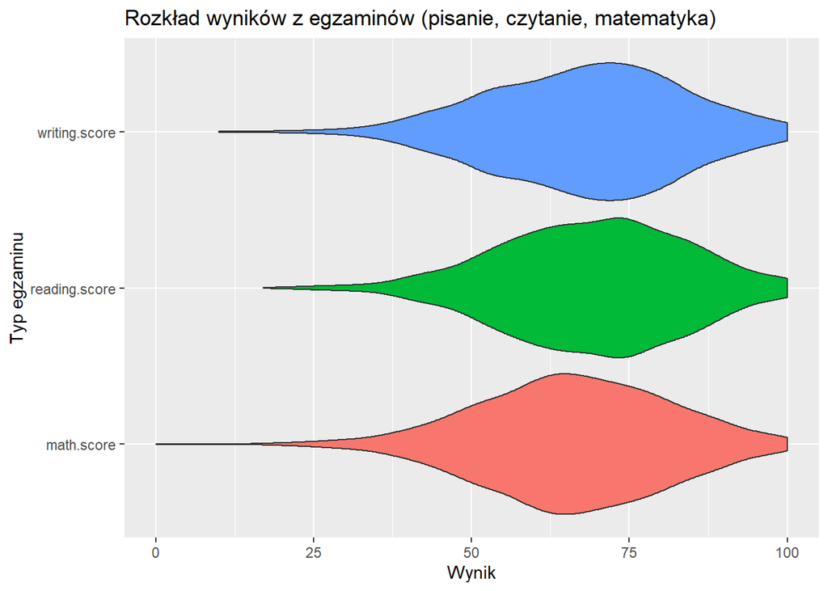

```r
df %>%
  pivot_longer(cols=c(math.score, reading.score, writing.score), names_to = "test_type", values_to = "score") %>%
  ggplot(aes(x=score, y=test_type, fill=test_type)) +
  geom_violin()+
  labs(title = "Rozkład wyników z egzaminów (pisanie, czytanie, matematyka)", y="Typ egzaminu", x="Wynik", color="Kurs przygotowawczy")+
  theme(legend.position = "none")
```

**Komentarz: Można zauważyć, że najczęściej występującym wynikiem z egzaminu z matematyki jest około 65% i jest to wynik o około 10 pkt. procentowy niższy od najczęściej uzyskiwanych wyników z egzaminów z czytania i pisania. Ponadto wyniki niższe od najczęściej występujących z czytania i pisania są bardziej równmiernie rozłożone niż te niższe od najczęstszego wyniku z matematyki, natomiast odwrotnie jest w przypadku wyników wyższych od najczęściej uzyskiwanych. Bardzo niskie wyniki uzyskiwane są przede wszystkim z matematyki (wynik mniejszy niż 10%).**

## Zadanie 2

Czy istnieje zauważalna różnica w wynikach między uczniami i uczennicami?

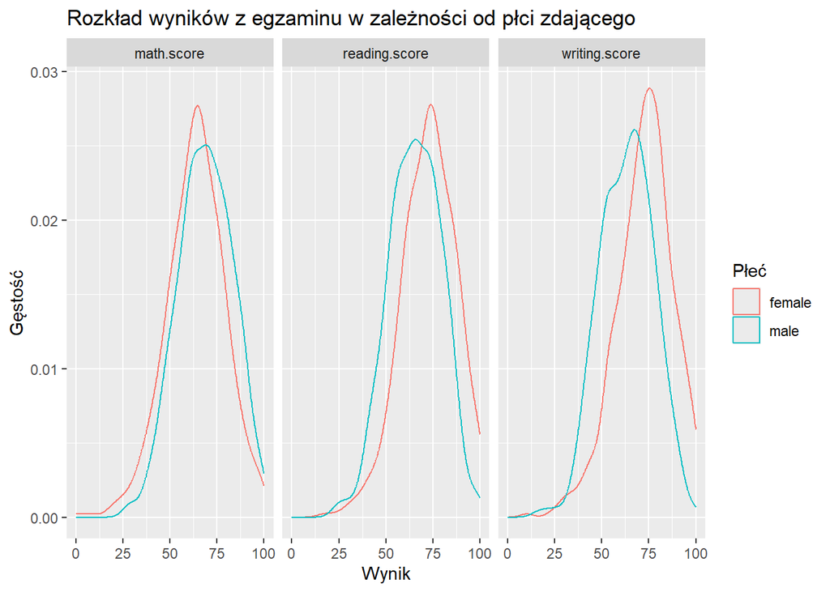

```r
df %>%
  pivot_longer(cols=c(math.score, reading.score, writing.score), names_to = "test_type", values_to = "score") %>%
  ggplot(aes( x=score, color=gender))+
  geom_density()+
  facet_wrap("test_type", nrow=1)+
  labs(title = "Rozkład wyników z egzaminu w zależności od płci zdającego", y="Gęstość", x="Wynik", color="Płeć")
```

**Komentarz: W przypadku egzaminu z matematyki możemy zauważyć, że nieco lepiej niż uczennice wypadają uczniowie; osiągają oni najczęściej wynik w okolicy 70%, podczas gdy uczennice osiągają najczęściej wynik w okolicy 63%-64%, wyniki niższe od najczęściej uzyskiwanych (z egzaminu z matematyki) są częściej uzyskiwane przez uczennice niż uczniów i odwrotnie w przypadku wyników wyższych. Zupełnie odwrotnie jest w przypadku egzaminów z pisania i czytania gdzie to uczennice radzą sobie lepiej niż uczniowie uzyskując z czytania i pisania najczęściej ok. 75% a uczniowie około 65%. Można próbować wytłumaczyć to zauważając, że to kobiety częściej mają lepiej rozwinięte umięjętności humanistyczne i mężczyźni śrenio lepiej radzą sobie w naukach ścisłych.*

## Zadanie 3

Czy uczniowie, którzy ukończyli kurs przygotowawczy, osiągają lepsze wyniki niż pozostali?

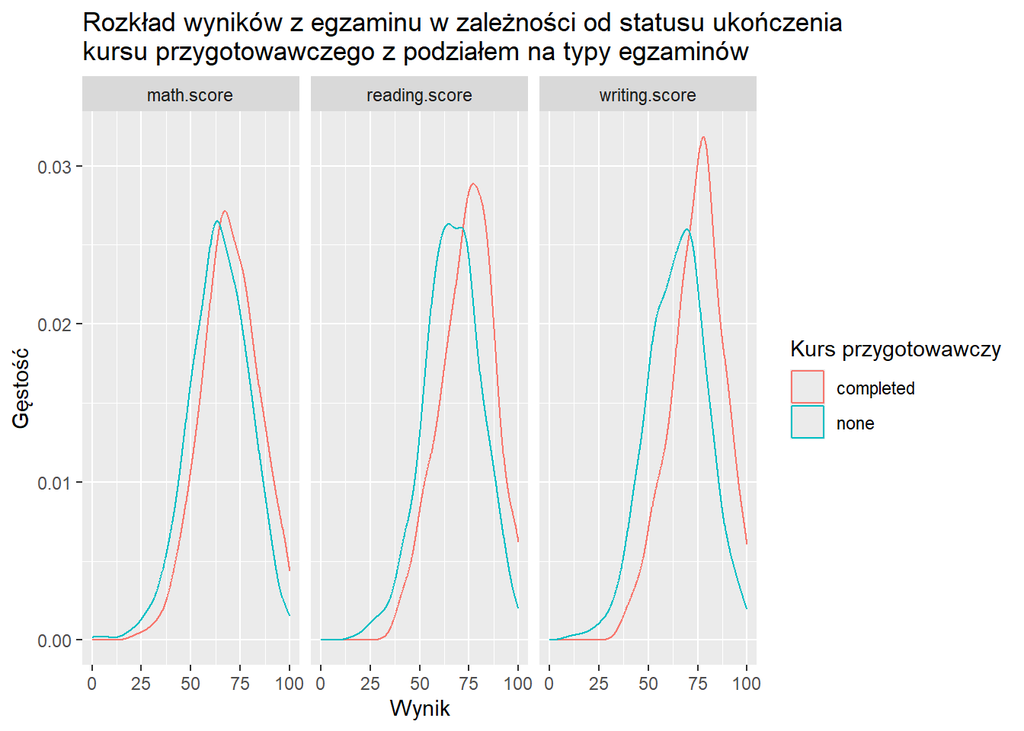

```r
df %>%
  pivot_longer(cols=c(math.score, reading.score, writing.score), names_to = "test_type", values_to = "score") %>%
  ggplot(aes( x=score, color=test.preparation.course))+
  geom_density()+
  facet_wrap("test_type", nrow=1)+
  labs(title = "Rozkład wyników z egzaminu w zależności od statusu ukończenia \nkursu przygotowawczego z podziałem na typy egzaminów", y="Gęstość", x="Wynik", color="Kurs przygotowawczy")
```

**Komentarz: Można zdecydowanie stwierdzić, że kurs przygotowawczy pozwala osiągnąć lepsze wyniki w porównaniu z wynikami osób bez takiego kursu, jednakże efektywność tego kursu różni się w zależności od przedmiotu. Jeżeli chodzi o matematykę, to poprawa jest niewielka, najczęściej uzyskiwany wynik z matematyki po kursie przygotowawczym jest o około 5 pkt. procentowy wyższy od najczęsciej uzsykiwanego przez osoby bez kursu. Natomiast w przypadku wyników z czytania i pisania można zauważyć, że kurs zdecydowanie pomaga uczniom, którzy najczęściej uzyskują z tych przedmiotów nieco ponad 75% i jest to wynik zdecydowanie dużo popularniejszy od innych w tej grupie osób, natomiast uczniowie bez kursu uzyskują gorsze wyniki i rozkład jest nieco bardziej równomierny. Ponadto wyniki mniejsze od ok. 30% z czytania i pisania praktycznie nie występują w grupie osób, które ukończyły kurs, podczas gdy w drugiej grupie osób liczba takich wyników jest zdecydowanie większa od 0. Taką efektywność kursu można wytłumaczyć tym, że matematyka jest przedmiotem wymagającym myślenia i tworzenia często nietypowych rozwiązań a umiętności takie jak ortografie czy czytanie, to coś czego można się po prostu nauczyć dużo ćwicząc.**

## Zadanie 4

Jaki jest związek między poziomem wykształcenia rodziców a średnimi wynikami uczniów?

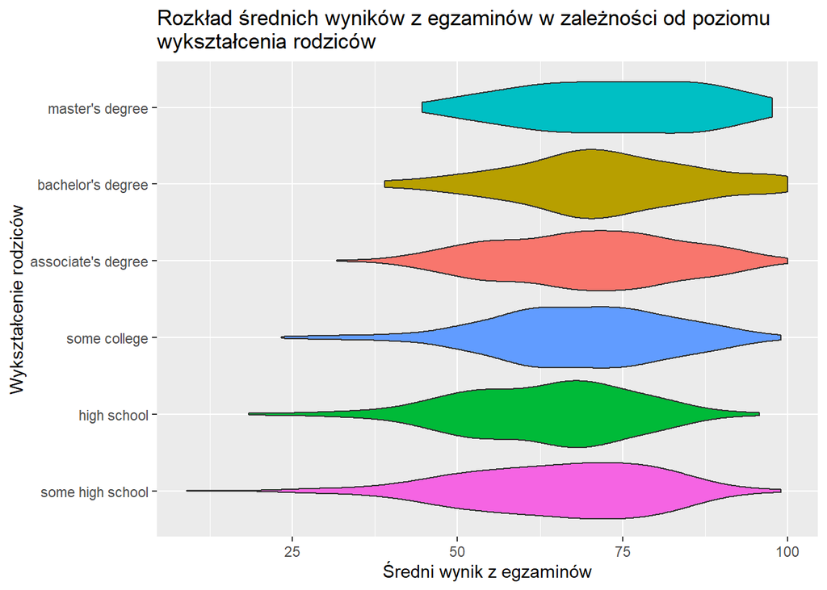

```r
df %>%
  mutate(mean_score = (math.score+writing.score+reading.score)/3) %>%
  ggplot(aes(x=mean_score, y=parental.level.of.education, fill=parental.level.of.education))+
  geom_violin()+
  scale_y_discrete(limits = c("some high school", "high school", "some college", "associate's degree", "bachelor's degree", "master's degree"))+
  labs(title = "Rozkład średnich wyników z egzaminów w zależności od poziomu \nwykształcenia rodziców", y="Wykształcenie rodziców", x="Średni wynik z egzaminów")+
  theme(legend.position = "none")
```

**Komentarz: Wyższy poziom wykształcenia rodziców ma pozytywny wpływ na średnie wyniki z egzaminów, aczkolwiek jeżeli rozważamy to jak często uczniowie osiągają słabe wyniki. To znaczy, że w przypadku dzieci lepiej wykształconych rodziców nie występują niskie wyniki (0%-30%). Jednakże i tak najczęściej najćzęściej osiągany średni wynik we wszystkich grupach jest podobny.**

## Zadanie 5

Czy płeć i wykształcenie rodzica wpływa na wynik z matematyki?

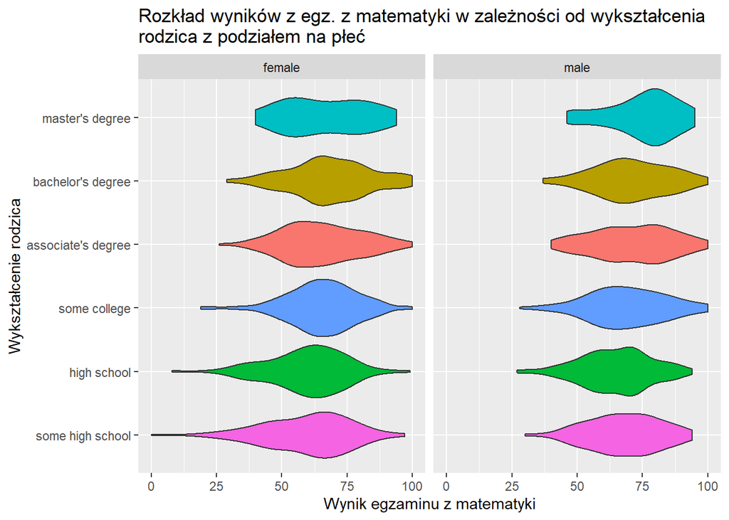

```r
df %>%
  ggplot(aes(x=math.score, y=parental.level.of.education, fill=parental.level.of.education))+
  geom_violin()+
  scale_y_discrete(limits = c("some high school", "high school", "some college", "associate's degree", "bachelor's degree", "master's degree"))+
  facet_wrap("gender", nrow=1)+
  labs(title = "Rozkład wyników z egz. z matematyki w zależności od wykształcenia \nrodzica z podziałem na płeć", y="Wykształcenie rodzica", x="Wynik egzaminu z matematyki")+
  theme(legend.position = "none")
```

## Zadanie 6

Czy istnieje zależność między wynikami z matematyki a wynikami z czytania lub pisania?

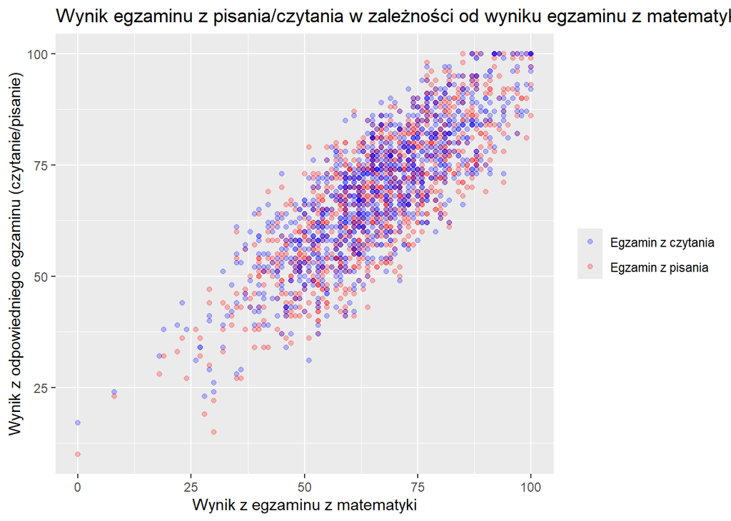

```r
df %>%
  ggplot(aes(x = math.score)) +
  geom_point(aes(y = writing.score, color = "Egzamin z pisania"), alpha = 0.25) +
  geom_point(aes(y = reading.score, color = "Egzamin z czytania"), alpha = 0.25) +
  scale_color_manual(values = c("Egzamin z pisania" = "red",
                                "Egzamin z czytania" = "blue"))+
  labs(y="Wynik z odpowiedniego egzaminu (czytanie/pisanie)", x="Wynik z egzaminu z matematyki", title="Wynik egzaminu z pisania/czytania w zależności od wyniku egzaminu z matematyki", color = NULL)
```